# Caret introudction

# Using your own model in `train`

The package contains a large number of predictive model interfaces. However, you may want to create your own because:

- you are testing out a novel model or the package doesn’t have a model that you are interested in
- you would like to run an existing model in the package your own way
- there are **pre-processing** or **sampling steps** not contained in the package or you just don’t like the way the package does things

You can still get the benefits of the `caret` infrastructure by creating your own model.

Currently, hen you specify the type of model that you are interested in (e.g. `type = "lda"`), the `train` function runs another function called `getModelInfo` to retrieve the specifics of that model from the existing catalog. For example:

```r
ldaModelInfo <- getModelInfo(model="lda",regex=FALSE)[[1]]
## Model components
names(ldaModelInfo)
```

```
##  [1] "label"      "library"    "loop"       "type"       "parameters"
##  [6] "grid"       "fit"        "predict"    "prob"       "predictors"
## [11] "tags"       "levels"     "sort"
```

To use your own model, you can pass a list of these components to `type`. This page will describe those components in detail.

## Illustrative example 1: SVMs with Laplacian Kernels

The package currently contains support vector machine (SVM) models using linear, polynomial and radial basis function kernels. The `kernlab` package has other functions, including the Laplacian Kernel. We will illustrate the model components for this model, which has two parameters: the standard cost parameter for SVMs and one kernel parameter (`sigma`)

## Model Components

You can pass a list of information to the `method` argument in `train`. For models that are built-in to the package, you can just pass the method name as before.

There are some basic components of the list for custom models. A brief description is below for each then, after setting up and example, each will be described in detail. The list should have the following elements:

- `library` is a character vector of package names that will be needed to fit the model or calculate predictions. NULL can also be used.
- `type` is a simple character vector with values `"Classification"`, `"Regression"` or both.
- `parameters` is a data frame with three simple attributes for each tuning parameter (if any): the argument name (e.g. mtry), the type of data in the parameter grid and textual labels for the parameter.
- `grid` is a function that is used to create the tuning grid (unless the user gives the exact values of the parameters via tuneGrid) fit is a function that fits the model
- `predict` is the function that creates predictions
- `prob` is a function that can be used to create class probabilities (if applicable) sort is a function that sorts the parameter from most complex to least
- `loop` is an **optional** function for advanced users for models that can create multiple submodel predictions from the same object.
- `levels` is an **optional** function, primarily for classification models using S4 methods to return the factor levels of the outcome.
- `tags` is an **optional** character vector that has subjects associated with the model, such as `Tree-Based Model` or `Embedded Feature Selection`. This string is used by the package to create additional documentation pages on the package website. label is an optional character string that names the model (e.g. “Linear Discriminant Analysis”).
- `predictors` is an **optional** function that returns a character vector that contains the names of the predictors that we used in the prediction equation.
- `varImp` is an **optional** function that calculates variable importance metrics for the model (if any).
- `oob` is another **optional** function that calculates out-of-bag performance estimates from the model object. Most models do not have this capability but some (e.g. random forests, bagged models) do.
- `notes` is an **optional** character vector that can be used to document non-obvious aspects of the model. For example, there are two Bayesian lasso models (`blasso` and `blassoAveraged`) and this field is used to describe the differences between the two models.
- `check` is an **optional** function that can be used to check the system/install to make sure that any atypical software requirements are available to the user. The input is pkg, which is the same character string given by the `library`. This function is run after the checking function to see if the packages specified in library are installed. As an example, the model `pythonKnnReg` uses certain python libraries and the user should have python and these libraries installed. The model file demonstrates how to check for python libraries prior to running the R model.

In the `caret` package, the subdirectory `models` has all the code for each model that `train` interfaces with and these can be used as prototypes for your model.

Let’s create a new model for a classification support vector machine using the Laplacian kernel function. We will use the `kernlab` package’s `ksvm` function. The kernel has two parameters: the standard cost parameter for SVMs and one kernel parameter (`sigma`).

To start, we’ll create a new list:

```r
lpSVM <- list(type="Classification",
              library="kernlab",
              loop=NULL)
```

This model can also be used to regression, but we will constratin things here for simplificity. For other SVM models, the type value would be `c("Classification", "Regression")`.

The `library` value checks to see if this package is installed and loads it whenever it is needed (e.g., before modeling or prediction). **Note:** `caret` will check to see if these packages are installed but will *not* explicitly load them. As such unctions that are used from the package should be referenced by namespace. This is discussed more below when describing the `fit` function.

### The parameters element

We have to create some basic information for the parameters in the form of a data frame. The first column is the name of the parameter. The convention is to use the argument name in the model function (e.g. the `ksvm` function here). Those values are `C` and `sigma`. Each is a number and we can give them labels of `"Cost"` and `"Sigma"`, respectively. The parameters element would then be:

```r
prm <- data.frame(parameter=c("C","Sigma"),
                  class=rep("numeric",2),
                  label=c("Cost","Sigma"))
```

Now, we assign it to the model list:

```r
lpSVM$parameters <- prm
summary(lpSVM)
```

```
##            Length Class      Mode
## type       1      -none-     character
## library    1      -none-     character
## loop       0      -none-     NULL
## parameters 3      data.frame list
```

Values of `type` can indicate numeric, character or logical data types.

### The `grid` Element

This should be a function that takes parameters: `x` and `y` (for the predictors and outcome data), `len` (the number of values per tuning parameter) as well as `search`. `len` is the value of `tuneLength` that is potentially passed in through `train`. `search` can be either `"grid"` or `"random"`. This can be used to setup a grid for searching or random values for random search.

The output should be a data frame of tuning parameter combinations with a column for each parameter. The column names should be the parameter name (e.g. the values of prm$parameter). In our case, let’s vary the cost parameter on the log 2 scale. For the sigma parameter, we can use the kernlab function sigest to pre-estimate the value. Following ksvm we take the average of the low and high estimates. Here is a function we could use:

```r
svmGrid <- function(x,y,len=NULL, search="grid"){
  library(kernlab)
  ## This produces low, middle and high value for sigma
  ## i.e. a vector with 3 elements
  sigmas <- kernlabb::sigest(as.matrix(x),na.action=na.omit, scaled=TRUE)
  ## To use a grid search
  if (search =="grid"){
    out <- expand.grid(sigma=mean(as.vector(sigmas[-2])),
                       C=2^(1:len)-3)
  }else{
    ## For random search, define ranges for the parameters then
    ## generate random values for them
    rng <- extendrange(log(sigmas),f=.75)
    out <- data.frame(sigma=exp(runif(len,min=rng[1],max=rng[2])),
                      C=2^runif(len,min=-5,max=8))
  }
  out
}
```

Why did we use `kernelab::sigest` instead of `sigest`? As previously mentioned, `caret` will not execute `library(kernlab)` unless you explicitly code it in these functions. Since it not explicityl loaded, you have to call it *using the namespace operator* `::`.

Again, the user can pass their own grid via `train`’s `tuneGrid` option or they can use this code to create a default grid. We assign this function to the overall model list:

```r
lpSVM$grid <- svmGrid
```

### The `fit` Element

Here is where we fit the model. This `fit` function has several arguments: - `x`, `y`: the current data used to fit the model - `wts`: optional instance weights (not applicable for this particular model) - `param`: the current tuning parameter values - `lev`: the class levels of the outcome (or NULL in regression) - `last`: a logical for whether the current fit is the final fit - `weights` - `classProbs`: a logical for whether class probabilities should be computed.

Here is something we could use for this model:

```r
svmFit <- function(x, y, wts, param, lev, last, weights, classProbs, ...) {
  kernlab::ksvm(
    x = as.matrix(x), y = y,
    kernel = "rbfdot",
    kpar = list(sigma = param$sigma),
    C = param$C,
    prob.model = classProbs,
    ...
    )
 }

lpSVM$fit <- svmFit
```

A few note about this: - Notice that the package is not loaded in the code. It is loaded prior to this function being called so it won’t hurt if you load it again (but that’s not needed). - The `ksvm` function requires a matrix or predictors. If the original data were a data frame, this would throw and error. - The tuning parameters are references in the `param` data frame. There is always a single row in this data frame. - The probability model is fit based on the value of `classProbs`. This value is determined by the value given in `trainControl`. - The three dots allow the user to pass options in from `train` to, in this case, the `ksvm` function. For example, if the use wanted to set the cache size for the function, they could list `cache = 80` and this argument will be pass from `train` to `ksvm`. - Any pre-processing that was requested in the call to train have been done. For example, if `preProc = "center`" was originally requested, the columns of `x` seen within this function are mean centered. - Again, the namespace operator `::` is used for `rbfdot` and `ksvm` to ensure that the function can be found.

### 13.3.4 The `predict` Element

This is a function that produces a vector or predictions. In our case these are class predictions but they could be numbers for regression models.

The arguments are:

- `modelFit`: the model produced by the `fit` code shown above.
- `newdata`: the predictor values of the instances being predicted (e.g. out-of-bag samples)
- `preProc`
- `submodels`: this an optional list of tuning parameters only used with the `loop` element discussed below. In most cases, it will be NULL.

Our function will be very simple:

```r
svmPred <- function(modelFit, newdata, preProc = NULL, submodels = NULL)
   kernlab::predict(modelFit, newdata)
lpSVM$predict <- svmPred
```

The function `predict.ksvm` will automatically create a factor vector as output. The function could also produce character values. Either way, the innards of `train` will make them factors and ensure that the same levels as the original data are used.

### 13.3.5 The `prob` element

If a regression model is being used or if the classification model does not create class probabilities a value of `NULL` can be used here instead of a function. Otherwise, the function arguments are the same as the `pred` function. The output should be a matrix or data frame of class probabilities with a column for each class. The column names should be the class levels.

We can use:

```r
svmProb <- function(modelFit, newdata, preProc = NULL, submodels = NULL)
  kernlab::predict(modelFit, newdata, type = "probabilities")
lpSVM$prob <- svmProb
```

If you look at some of the SVM examples in the models directory, the real functions used by train are much more complicated so that they can deal with model failures, probabilities that do not sum to 1 etc.

## The sort element

This is an optional function that sorts the tuning parameters from the simplest model to the most complex. There are times where this ordering is not obvious. This information is used when the performance values are tied across multiple parameters. We would probably want to choose the least complex model in those cases.

Here, we will sort by the cost value. Smaller values of `C` produce smoother class boundaries than larger values:

```r
svmSort <- function(x) x[order(x$C),]
lpSVM$sort <- svmSort
```

### The `levels` element

`train` ensures that classification models always predict factors with the same levels. To do this at prediction time, the package needs to know the levels from the model object (specifically, the `finalModels` slot of the `train` object).

For model functions using `S3` methods, `train` automatically attaches a character vector called `obsLevels` to the object and the package code uses this value. However, this strategy does not work for `S4` methods. In these cases, the package will use the code found in the `levels` slot of the model list.

For example, the `ksvm` function uses `S4` methods but, unlike most model functions, has a built–in function called `lev` that will extract the class `levels (if any). In this case, our levels code would be:

```r
lpSVM$levels <- function(x) kernlab::lev(x)
```

In most other cases, the levels will beed to be extracted from data contained in the fitted model object. As another example, objects created using the `ctree` function in the `party` package would need to use:

```r
function(x) levels(x@data@get("response")[,1])
```

```
## function(x) levels(x@data@get("response")[,1])
```

Again, this is only used for classification models using `S4` methods. We should now be ready to fit our model.

```r
library(mlbench)
data(Sonar)

library(caret)
set.seed(998)
inTraining <- createDataPartition(Sonar$Class, p = .75, list = FALSE)
training <- Sonar[ inTraining,]
testing  <- Sonar[-inTraining,]

fitControl <- trainControl(method = "repeatedcv",
                           ## 10-fold CV...
                           number = 10,
                           ## repeated ten times
                           repeats = 10)

set.seed(825)
Laplacian <- train(Class ~ ., data = training,
                   method = lpSVM,
                   preProc = c("center", "scale"),
                   tuneLength = 8,
                   trControl = fitControl)
Laplacian
```

[output not shown]

```r
ggplot(Lapacian)+scale_x_log10()
```

## Illustrative Example 2: Something more complicated - `LogitBoost`

### The loop element

This function can be used to create custom loops for models to tune over. In most cases, the function can just retrun the existing tuning grid.

For example, a `LogitBoost` model can be trained over the number of boosting iterationds. IN the `caTools` package, the `LogitBoost` function can be used to fit this model. For example:

```r
library(caTools)

mod <- LogitBoost(as.matrix(x), y, nIter = 51)
```

If we were to tune the model evaluating models where the number of iterations was 11, 21, 31, 41 and 51, the grid could be

```r
lbGrid <- data.frame(nIter = seq(11, 51, by = 10))
lbGrid
```

| nIter |
| --- |
| 11 |
| 21 |
| 31 |
| 41 |
| 51 |

During resampling, `train` could loop over all five rows in `lbGrid` and fit five models. However, the `predict.LogitBoost` function has an argument called `nIter` that can produce, in this case, predictions from `mod` for all five models.

The terminology used here is that `nIter` is a sequential tuning parameter (and the other parameters would be considered *fixed*).

The `loop` argument for model is used to produce two objects - `loop`: this is the actual loop that is used by `train`. - `submodels` is a *list* that has as many elements as there are rows in `loop`. The list has all the extra parameter settings that can be derived for each model.

Going back to the `LogitBoost` example, we could have:

```r
loop <- data.frame(.nIter=51)
loop
```

| .nIter |
| --- |
| 51 |

```r
submodels <- list(data.frame(nIter=seq(11,41,by=10)))
submodels
```

```
## [[1]]
##   nIter
## 1    11
## 2    21
## 3    31
## 4    41
```

For this case, `train` first fits the `nIter = 51` model. When the model is predicted, that code has a for loop that iterates over the elements of `submodel[[1]]` to get the predictions for the other 4 models.

In the end, predictions for all five models (for `nIter = seq(11, 51, by = 10)`) with a single model fit.

There are other models built-in to `caret` that are used this way. There are a number of models that have multiple sequential tuning parameters.

If the `loop` argument is left `NULL` the results of `tuneGrid` are used as the simple loop and is recommended for most situations. Note that the machinery that is used to “derive” the extra predictions is up to the user to create, typically in the `predict` and `prob` elements of the custom model object.

For the `LogitBoost` model, some simple code to create these objects would be:

```r
fullGrid <- data.frame(nIter=seq(11,51,by=10))

## Get the largest value of nIter to fit the "full" model
loop <- fullGrid[which.max(fullGrid$nIter),,drop=FALSE]
loop
```

|  | nIter |
| --- | --- |
| 5 | 51 |

```r
submodels <- fullGrid[-which.max(fullGrid$nIter),,drop=FALSE]
## This needs to be encased in a list in case there are more
## than one tuning parameter
submodels <- list(submodels)
submodels
```

```
## [[1]]
##   nIter
## 1    11
## 2    21
## 3    31
## 4    41
```

For the `LogitBoost` custom model object, we could use this code in the `predict` slot:

```r
lbPred <- function(modelFit, newdata, preProc = NULL, submodels = NULL) {
  ## This model was fit with the maximum value of nIter
  out <- caTools::predict.LogitBoost(modelFit, newdata, type="class")

  ## In this case, 'submodels' is a data frame with the other values of
  ## nIter. We loop over these to get the other predictions.
  if(!is.null(submodels)) {
    ## Save _all_ the predictions in a list
    tmp <- out
    out <- vector(mode = "list", length = nrow(submodels) + 1)
    out[[1]] <- tmp

    for(j in seq(along = submodels$nIter)) {
      out[[j+1]] <- caTools::predict.LogitBoost(
        modelFit,
        newdata,
        nIter = submodels$nIter[j])

    }
  }
  out
}
```

A few more notes:

- The code in the `fit` element does not have to change.
- The `prob` slot works in the same way. The only difference is that the values saved in the outgoing lists are matrices or data frames of probabilities for each class.
- After model training (i.e. predicting new samples), the value of `submodels` is set to `NULL` and the code produces a single set of predictions.
- If the model had one sequential parameter and one fixed parameter, the `loop` data frame would have two columns (one for each parameter). If the model is tuned over more than one value of the fixed parameter, the `submodels` list would have more than one element. If `loop` had 10 rows, then `length(submodels)` would be `10` and `loop[i,]` would be linked to `submodels[[i]]`.
- In this case, the prediction function was called by namespace too (i.e. `caTools::predict.LogitBoost`). This may not seem necessary but what functions are available can vary depending on what parallel processing technology is being used. For example, the nature of forking used by `doMC` and `doParallel` tends to have easier access to functions while PSOCK methods in doParallel do not. It may be easier to take the safe path of using the namespace operator wherever possible to avoid errors that are difficult to track down.

Here is a slimmed down version of the logitBoost code already in the package:

```r
lbFuncs <- list(library = "caTools",
                loop = function(grid) {
                  loop <- grid[which.max(grid$nIter),,drop = FALSE]
                  submodels <- grid[-which.max(grid$nIter),,drop = FALSE]
                  submodels <- list(submodels)
                  list(loop = loop, submodels = submodels)
                },
                type = "Classification",
                parameters = data.frame(parameter = 'nIter',
                                        class = 'numeric',
                                        label = '# Boosting Iterations'),
                grid = function(x, y, len = NULL, search = "grid") {
                  out <- if(search == "grid")
                    data.frame(nIter = 1 + ((1:len)*10)) else
                      data.frame(nIter = sample(1:500, size = len))
                  out
                },
                fit = function(x, y, wts, param, lev, last, weights, classProbs, ...) {
                  caTools::LogitBoost(as.matrix(x), y, nIter = param$nIter)
                },
                predict = function(modelFit, newdata, preProc = NULL, submodels = NULL) {
                  out <- caTools::predict.LogitBoost(modelFit, newdata, type="class")
                  if(!is.null(submodels)) {
                    tmp <- out
                    out <- vector(mode = "list", length = nrow(submodels) + 1)
                    out[[1]] <- tmp

                    for(j in seq(along = submodels$nIter)) {
                      out[[j+1]] <- caTools::predict.LogitBoost(
                        modelFit,
                        newdata,
                        nIter = submodels$nIter[j]
                        )
                    }
                  }
                  out
                },
                prob = NULL,
                sort = function(x) x)
```

Should you care about this? Let’s tune the model over the same dataset for the SVM model above and see how long it takes:

```r
set.seed(825)
lb1 <- system.time(train(Class ~ ., data = training,
                         method = lbFuncs,
                         tuneLength = 3,
                         trControl = fitControl))
lb1
```

[output not shown]

```r
## Now get rid of the submodel parts
lbFuncs2 <- lbFuncs
lbFuncs2$predict <- function(modelFit, newdata, preProc = NULL, submodels = NULL)
  caTools::predict.LogitBoost(modelFit, newdata, type = "class")
lbFuncs2$loop <- NULL

set.seed(825)
lb2 <- system.time(train(Class ~ ., data = training,
                         method = lbFuncs2,
                         tuneLength = 3,
                         trControl = fitControl))
lb2
```

```r
bigGrid <- data.frame(nIter=seq(1,151,by=10))
results <- bigGrid
results$SpeedUp <- NA

for(i in 2:nrow(bigGrid)){
  rm(lb1, lb2)
  set.seed(825)
  lb1 <- system.time(train(Class ~ ., data = training,
                           method = lbFuncs,
                           tuneGrid = bigGrid[1:i,,drop = FALSE],
                           trControl = fitControl))

  set.seed(825)
  lb2 <- system.time(train(Class ~ ., data = training,
                           method = lbFuncs2,
                           tuneGrid = bigGrid[1:i,,drop = FALSE],
                           trControl = fitControl))
  results$SpeedUp[i] <- lb2[3]/lb1[3]
  }

ggplot(results, aes(x = nIter, y = SpeedUp)) +
  geom_point() + geom_smooth(method = "lm") +
  xlab("LogitBoost Iterations") +
  ylab("Speed-Up")
```

[output not shown]

Note: The previous examples were run using parallel processing. The remainder in this chapter are run sequentially and, for simplicity, the namespace operator is not used in the custom code modules below.

## Illustrative Example3: Nonstandard Formulas

(Note: the previous third illustration (“SMOTE During Resampling”) is no longer needed due to the inclusion of subsampling via `train`.)

One limitation of `train` is that it requires the use of basic model formulas. There are several functions that use special formulas or operators on predictors that won’t (and perhaps should not) work in the top level call to `train`. However, we can still fit these models.

Here is an example using the `mboost` function in the **mboost** package from the help page.

```r
# install.packages("mboost")
# install.packages("TH.data")

library(mboost)
data("bodyfat", package="TH.data")

head(bodyfat)
```

|  | age | DEXfat | waistcirc | hipcirc | elbowbreadth | kneebreadth | anthro3a | anthro3b | anthro3c | anthro4 |
| --- | --- | --- | --- | --- | --- | --- | --- | --- | --- | --- |
| 47 | 57 | 41.68 | 100.0 | 112.0 | 7.1 | 9.4 | 4.42 | 4.95 | 4.50 | 6.13 |
| 48 | 65 | 43.29 | 99.5 | 116.5 | 6.5 | 8.9 | 4.63 | 5.01 | 4.48 | 6.37 |
| 49 | 59 | 35.41 | 96.0 | 108.5 | 6.2 | 8.9 | 4.12 | 4.74 | 4.60 | 5.82 |
| 50 | 58 | 22.79 | 72.0 | 96.5 | 6.1 | 9.2 | 4.03 | 4.48 | 3.91 | 5.66 |
| 51 | 60 | 36.42 | 89.5 | 100.5 | 7.1 | 10.0 | 4.24 | 4.68 | 4.15 | 5.91 |
| 52 | 61 | 24.13 | 83.5 | 97.0 | 6.5 | 8.8 | 3.55 | 4.06 | 3.64 | 5.14 |

```r
mod <- mboost(DEXfat ~ btree(age) + bols(waistcirc) + bbs(hipcirc),
              data = bodyfat)
mod
```

```
##
##   Model-based Boosting
##
## Call:
## mboost(formula = DEXfat ~ btree(age) + bols(waistcirc) + bbs(hipcirc),     data = bodyfat)
##
##
##   Squared Error (Regression)
##
## Loss function: (y - f)^2
##
##
## Number of boosting iterations: mstop = 100
## Step size:  0.1
## Offset:  30.78282
## Number of baselearners:  3
```

```r
# model based boosting
```

We can create a custom model that mimics this code so that we can obtain resampling estimates for this specific model:

```r
modelInfo <- list(label = "Model-based Gradient Boosting",
                  library = "mboost",
                  type = "Regression",
                  parameters = data.frame(parameter = "parameter",
                                          class = "character",
                                          label = "parameter"),
                  grid = function(x, y, len = NULL, search = "grid")
                    data.frame(parameter = "none"),
                  loop = NULL,
                  fit = function(x, y, wts, param, lev, last, classProbs, ...) {
                    ## mboost requires a data frame with predictors and response
                    dat <- if(is.data.frame(x)) x else as.data.frame(x)
                    dat$DEXfat <- y
                    mod <- mboost(
                      DEXfat ~ btree(age) + bols(waistcirc) + bbs(hipcirc),
                      data = dat
                      )
                    },
                  predict = function(modelFit, newdata, submodels = NULL) {
                    if(!is.data.frame(newdata)) newdata <- as.data.frame(newdata)
                    ## By default a matrix is returned; we convert it to a vector
                    predict(modelFit, newdata)[,1]
                  },
                  prob = NULL,
                  predictors = function(x, ...) {
                    unique(as.vector(variable.names(x)))
                  },
                  tags = c("Ensemble Model", "Boosting", "Implicit Feature Selection"),
                  levels = NULL,
                  sort = function(x) x)

## Just use the basic formula method so that these predictors
## are passed 'as-is' into the model fitting and prediction
## functions.
set.seed(307)
mboost_resamp <- train(DEXfat ~ age + waistcirc + hipcirc,
                       data = bodyfat,
                       method = modelInfo,
                       trControl = trainControl(method = "repeatedcv",
                                                repeats = 5))
```

[output not shown]

```r
mboost_resamp
```

```
## Model-based Gradient Boosting
##
## 71 samples
##  3 predictor
##
## No pre-processing
## Resampling: Cross-Validated (10 fold, repeated 5 times)
## Summary of sample sizes: 64, 63, 65, 65, 64, 63, ...
## Resampling results:
##
##   RMSE      Rsquared   MAE
##   4.024352  0.9057944  3.156712
```

## Illustraive example 4: PLS feature extraction pre-processing

PCA is a common tool for feature extraction prior to modeling but is *unsupervised* **Partial Least Squares (PLS)** is essentially a supervised version of PCA. For some data sets, there may be some benefit to using PLS to generate new features from the original data (the PLS scores) then use those as an input into a different predictive model. PLS requires parameter tuning. In the example below, we use PLS on a data set with highly correlated predictors then use the PLS scores in a random forest model.

The “trick” here is to save the PLS loadings along with the random forest model fit so that the loadings can be used on future samples for prediction. Also, the PLS and random forest models are jointly tuned instead of an initial modeling process that finalizes the PLS model, then builds the random forest model separately. In this was we optimize both at once. Another important point is that the resampling results reflect the variability in the random forest and PLS models. If we did PLS up-front then resampled the random forest model, we would under-estimate the noise in the modeling process.

The tecator spectroscopy data are used:

```r
data(tecator)

set.seed(930)
colnames(absorp) <- paste("x", 1:ncol(absorp))

## We will model the protein content data
trainMeats <- createDataPartition(endpoints[,3], p = 3/4)
absorpTrain  <- absorp[trainMeats[[1]], ]
proteinTrain <- endpoints[trainMeats[[1]], 3]
absorpTest   <- absorp[-trainMeats[[1]], ]
proteinTest  <- endpoints[-trainMeats[[1]], 3]
```

Here is the model code:

```r
pls_rf <- list(label = "PLS-RF",
               library = c("pls", "randomForest"),
               type = "Regression",
               ## Tune over both parameters at the same time
               parameters = data.frame(parameter = c('ncomp', 'mtry'),
                                       class = c("numeric", 'numeric'),
                                       label = c('#Components',
                                                 '#Randomly Selected Predictors')),
               grid = function(x, y, len = NULL, search = "grid") {
                 if(search == "grid") {
                   grid <- expand.grid(ncomp = seq(1, min(ncol(x) - 1, len), by = 1),
                                       mtry = 1:len)
                   } else {
                     grid <- expand.grid(ncomp = sample(1:ncol(x), size = len),
                                         mtry = sample(1:ncol(x), size = len))
                     }
                 ## We can't have mtry > ncomp
                 grid <- subset(grid, mtry <= ncomp)
                 },
               loop = NULL,
               fit = function(x, y, wts, param, lev, last, classProbs, ...) {
                 ## First fit the pls model, generate the training set scores,
                 ## then attach what is needed to the random forest object to
                 ## be used later

                 ## plsr only has a formula interface so create one data frame
                 dat <- x
                 dat$y <- y
                 pre <- plsr(y~ ., data = dat, ncomp = param$ncomp)
                 scores <- predict(pre, x, type = "scores")
                 colnames(scores) <- paste("score", 1:param$ncomp, sep = "")
                 mod <- randomForest(scores, y, mtry = param$mtry, ...)
                 mod$projection <- pre$projection
                 mod
                 },
               predict = function(modelFit, newdata, submodels = NULL) {
                 ## Now apply the same scaling to the new samples
                 scores <- as.matrix(newdata)  %*% modelFit$projection
                 colnames(scores) <- paste("score", 1:ncol(scores), sep = "")
                 scores <- as.data.frame(scores)
                 ## Predict the random forest model
                 predict(modelFit, scores)
                 },
               prob = NULL,
               varImp = NULL,
               predictors = function(x, ...) rownames(x$projection),
               levels = function(x) x$obsLevels,
               sort = function(x) x[order(x[,1]),])
```

```r
meatCtrl <- trainControl(method = "repeatedcv", repeats = 5)

## These will take a while for these data
set.seed(184)
plsrf <- train(x = as.data.frame(absorpTrain), y = proteinTrain,
               method = pls_rf,
               preProc = c("center", "scale"),
               tuneLength = 10,
               ntree = 1000,
               trControl = meatCtrl)
ggplot(plsrf, plotType = "level")
```

```r
## How does random forest do on its own?
set.seed(184)
rfOnly <- train(absorpTrain, proteinTrain,
                method = "rf",
                tuneLength = 10,
                ntree = 1000,
                trControl = meatCtrl)
getTrainPerf(rfOnly)
```

```r
## How does random forest do on its own?
set.seed(184)
plsOnly <- train(absorpTrain, proteinTrain,
                 method = "pls",
                 tuneLength = 20,
                 preProc = c("center", "scale"),
                 trControl = meatCtrl)
getTrainPerf(plsOnly)
```

```r
postResample(predict(plsrf, absorpTest), proteinTest)
```

```r
postResample(predict(rfOnly, absorpTest), proteinTest)
```

```r
ostResample(predict(plsOnly, absorpTest), proteinTest)
```

## 13.8 illustrative example 5: Optimizing probability threshold for class imbalances

This description was originally posted on [this blog](http://appliedpredictivemodeling.com/blog/).

One of the toughest problems in predictive model occurs when the classes have a severe imbalance. In our book, we spend an entire chapter on this subject itself. One consequence of this is that the performance is generally very biased against the class with the smallest frequencies. For example, if the data have a majority of samples belonging to the first class and very few in the second class, most predictive models will maximize accuracy by predicting everything to be the first class. As a result there’s usually great sensitivity but poor specificity. As a demonstration will use a simulation system [described here](http://appliedpredictivemodeling.com/blog/2013/4/11/a-classification-simulation-system). By default it has about a 50-50 class frequency but we can change this by altering the function argument called `intercept`:

```r
library(caret)

set.seed(442)
trainingSet <- twoClassSim(n = 500, intercept = -16)
testingSet  <- twoClassSim(n = 500, intercept = -16)

## Class frequencies
table(trainingSet$Class)
```

```
##
## Class1 Class2
##    450     50
```

There is almost a 9:1 imbalance in these data. Let’s use a standard random forest model with these data using the default value of `mtry`. We’ll also use repeated 10-fold cross validation to get a sense of performance:

```r
set.seed(949)
mod0 <- train(Class ~ ., data = trainingSet,
              method = "rf",
              metric = "ROC",
              tuneGrid = data.frame(mtry = 3),
              ntree = 1000,
              trControl = trainControl(method = "repeatedcv",
                                       repeats = 5,
                                       classProbs = TRUE,
                                       summaryFunction = twoClassSummary))
getTrainPerf(mod0)
```

| TrainROC | TrainSens | TrainSpec | method |
| --- | --- | --- | --- |
| 0.9576444 | 0.9982222 | 0.332 | rf |

```r
## Get the ROC curve
??roc
library()
roc0 <- roc(testingSet$Class,
            predict(mod0, testingSet, type = "prob")[,1],
            levels = rev(levels(testingSet$Class)))
roc0
```

```r
## Now plot
plot(roc0, print.thres = c(.5), type = "S",
     print.thres.pattern = "%.3f (Spec = %.2f, Sens = %.2f)",
     print.thres.cex = .8,
     legacy.axes = TRUE)
```

One of the most common ways to deal with this is to determine an alternate probability cut off using the ROC curve. But to do this well, another set of data (not the test set) is needed to set the cut off and the test set is used to validate it. We don’t have a lot of data this is difficult since we will be spending some of our data just to get a single cut off value.

Alternatively the model can be tuned, using resampling, to determine any model tuning parameters as well as an appropriate cut off for the probabilities.

Suppose the model has one tuning parameter and we want to look at four candidate values for tuning. Suppose we also want to tune the probability cut off over 20 different thresholds. Now we have to look at 20×4=80 different models (and that is for each resample). One other feature that has been opened up his ability to use sequential parameters: these are tuning parameters that don’t require a completely new model fit to produce predictions. In this case, we can fit one random forest model and get it’s predicted class probabilities and evaluate the candidate probability cutoffs using these same hold-out samples. Here is what the model code looks like:

```r
# Get the model code for the original random forest method:

thresh_code <- getModelInfo("rf", regex = FALSE)[[1]]
thresh_code$type <- c("Classification")
## Add the threshold as another tuning parameter
thresh_code$parameters <- data.frame(parameter = c("mtry", "threshold"),
                                     class = c("numeric", "numeric"),
                                     label = c("#Randomly Selected Predictors",
                                               "Probability Cutoff"))
## The default tuning grid code:
thresh_code$grid <- function(x, y, len = NULL, search = "grid") {
  p <- ncol(x)
  if(search == "grid") {
    grid <- expand.grid(mtry = floor(sqrt(p)),
                        threshold = seq(.01, .99, length = len))
    } else {
      grid <- expand.grid(mtry = sample(1:p, size = len),
                          threshold = runif(1, 0, size = len))
      }
  grid
  }

## Here we fit a single random forest model (with a fixed mtry)
## and loop over the threshold values to get predictions from the same
## randomForest model.
thresh_code$loop = function(grid) {
  library(plyr)
  loop <- ddply(grid, c("mtry"),
                function(x) c(threshold = max(x$threshold)))
  submodels <- vector(mode = "list", length = nrow(loop))
  for(i in seq(along = loop$threshold)) {
    index <- which(grid$mtry == loop$mtry[i])
    cuts <- grid[index, "threshold"]
    submodels[[i]] <- data.frame(threshold = cuts[cuts != loop$threshold[i]])
    }
  list(loop = loop, submodels = submodels)
  }

## Fit the model independent of the threshold parameter
thresh_code$fit = function(x, y, wts, param, lev, last, classProbs, ...) {
  if(length(levels(y)) != 2)
    stop("This works only for 2-class problems")
  randomForest(x, y, mtry = param$mtry, ...)
  }

## Now get a probability prediction and use different thresholds to
## get the predicted class
thresh_code$predict = function(modelFit, newdata, submodels = NULL) {
  class1Prob <- predict(modelFit,
                        newdata,
                        type = "prob")[, modelFit$obsLevels[1]]
  ## Raise the threshold for class #1 and a higher level of
  ## evidence is needed to call it class 1 so it should
  ## decrease sensitivity and increase specificity
  out <- ifelse(class1Prob >= modelFit$tuneValue$threshold,
                modelFit$obsLevels[1],
                modelFit$obsLevels[2])
  if(!is.null(submodels)) {
    tmp2 <- out
    out <- vector(mode = "list", length = length(submodels$threshold))
    out[[1]] <- tmp2
    for(i in seq(along = submodels$threshold)) {
      out[[i+1]] <- ifelse(class1Prob >= submodels$threshold[[i]],
                           modelFit$obsLevels[1],
                           modelFit$obsLevels[2])
      }
    }
  out
  }

## The probabilities are always the same but we have to create
## mulitple versions of the probs to evaluate the data across
## thresholds
thresh_code$prob = function(modelFit, newdata, submodels = NULL) {
  out <- as.data.frame(predict(modelFit, newdata, type = "prob"))
  if(!is.null(submodels)) {
    probs <- out
    out <- vector(mode = "list", length = length(submodels$threshold)+1)
    out <- lapply(out, function(x) probs)
    }
  out
  }
```

Basically, we define a list of model components (such as the fitting code, the prediction code, etc.) and feed this into the train function instead of using a pre-listed model string (such as method = “rf”). For this model and these data, there was an 8% increase in training time to evaluate 20 additional values of the probability cut off.

How do we optimize this model? Normally we might look at the area under the ROC curve as a metric to choose our final values. In this case the ROC curve is independent of the probability threshold so we have to use something else. A common technique to evaluate a candidate threshold is see how close it is to the perfect model where sensitivity and specificity are one. Our code will use the distance between the current model’s performance and the best possible performance and then have train minimize this distance when choosing it’s parameters. Here is the code that we use to calculate this:

```r
library(caret)

fourStats <- function (data, lev = levels(data$obs), model = NULL) {
  ## This code will get use the area under the ROC curve and the
  ## sensitivity and specificity values using the current candidate
  ## value of the probability threshold.
  out <- c(twoClassSummary(data, lev = levels(data$obs), model = NULL))

  ## The best possible model has sensitivity of 1 and specificity of 1.
  ## How far are we from that value?
  coords <- matrix(c(1, 1, out["Spec"], out["Sens"]),
                   ncol = 2,
                   byrow = TRUE)
  colnames(coords) <- c("Spec", "Sens")
  rownames(coords) <- c("Best", "Current")
  c(out, Dist = dist(coords)[1])
}

set.seed(949)
mod1 <- train(Class ~ ., data = trainingSet,
              method = thresh_code,
              ## Minimize the distance to the perfect model
              metric = "Dist",
              maximize = FALSE,
              tuneLength = 20,
              ntree = 1000,
              trControl = trainControl(method = "repeatedcv",
                                       repeats = 5,
                                       classProbs = TRUE,
                                       summaryFunction = fourStats))

mod1
```

```r
library(reshape2)
metrics <- mod1$results[, c(2, 4:6)]
metrics <- melt(metrics, id.vars = "threshold",
                variable.name = "Resampled",
                value.name = "Data")

ggplot(metrics, aes(x = threshold, y = Data, color = Resampled)) +
  geom_line() +
  ylab("") + xlab("Probability Cutoff") +
  theme(legend.position = "top")
```

One great thing about this code is that it will automatically apply the optimized probability threshold when predicting new samples.

## Illustrative example 6: Offset in generalized linear models

We can write a small custom method to duplicate this model. Two details of note:

- If we have factors in the data and do not want `train` to convert them to dummy variables, the formula method for train should be avoided. We can let `glm` do that inside the custom method. This would help `glm` understand that the dummy variable columns came from the same original factor. This will avoid errors in other functions used with `glm` (e.g. `anova`).
- The slot for `x` should include any variables that are on the right-hand side of the model formula, including the offset column.

Here is the custom model:

```r
offset_mod <- getModelInfo("glm", regex = FALSE)[[1]]
offset_mod$fit <- function(x, y, wts, param, lev, last, classProbs, ...) {
  dat <- if(is.data.frame(x)) x else as.data.frame(x)
  dat$Postwt <- y
  glm(Postwt ~ Prewt + Treat + offset(Prewt), family = gaussian, data = dat)
}

mod <- train(x = anorexia[, 1:2], y = anorexia$Postwt, method = offset_mod)
coef(mod$finalModel)
```

# Adaptive Resampling

Models can benefit significantly from tuning but the optimal values are rarely known beforehand. `train` can be used to define a grid of possible points and resampling can be used to generate good estimates of performance for each tuning parameter combination.

However, in the nominal resampling process, all the tuning parameter combinations are computed for all the resamples before a choice is made about which parameters are good and which are poor.

`caret` contains the ability to adaptively resample the tuninig parameter grid in a way that concentrates on values that are in the neighborhood of the optimal settings. See [this paper](https://arxiv.org/abs/1405.6974).

To illustrate, we will use the Sonar data from one of the previous pages.

```r
library(mlbench)
data("Sonar")

library(caret)

inTraining <- createDataPartition(Sonar$Class, p=.75, list=FALSE)
training <- Sonar[inTraining,]
testing <- Sonar[-inTraining,]
```

We will tune a support vector machine model using the same tuning strategy as before but with [random search](https://topepo.github.io/caret/random-hyperparameter-search.html):

```r
svmControl <- trainControl(method = "repeatedcv",
                           number = 10, repeats = 10,
                           classProbs = TRUE,
                           summaryFunction = twoClassSummary,
                           search = "random")
set.seed(825)
svmFit <- train(Class ~ ., data = training,
                method = "svmRadial",
                trControl = svmControl,
                preProc = c("center", "scale"),
                metric = "ROC",
                tuneLength = 15)
svmFit
```

```
## Support Vector Machines with Radial Basis Function Kernel
##
## 157 samples
##  60 predictor
##   2 classes: 'M', 'R'
##
## Pre-processing: centered (60), scaled (60)
## Resampling: Cross-Validated (10 fold, repeated 10 times)
## Summary of sample sizes: 141, 141, 142, 141, 141, 142, ...
## Resampling results across tuning parameters:
##
##   sigma        C             ROC        Sens       Spec
##   0.001762205    0.07151747  0.8261508  0.5013889  0.8791071
##   0.002009736  113.04693607  0.8854712  0.8454167  0.7592857
##   0.002039922  171.55325987  0.8869519  0.8436111  0.7664286
##   0.002554611  170.97876908  0.8959970  0.8545833  0.7732143
##   0.003056140    0.27512524  0.8272247  0.5645833  0.8423214
##   0.003229103    0.06530343  0.8250818  0.5266667  0.8708929
##   0.003548214    0.03174726  0.8250843  0.5373611  0.8625000
##   0.005031725    9.48257431  0.8997569  0.8343056  0.7732143
##   0.006202988  110.85514925  0.9230332  0.8888889  0.7962500
##   0.006841192    0.74677405  0.8816022  0.7961111  0.7437500
##   0.007744235    4.99791627  0.9176538  0.8670833  0.7966071
##   0.016339163   20.36369457  0.9536012  0.9238889  0.8317857
##   0.017966687  459.42513969  0.9537946  0.9256944  0.8350000
##   0.038701701    9.53882007  0.9473264  0.9355556  0.8078571
##   0.068469613  275.28084205  0.9362872  0.9305556  0.7316071
##
## ROC was used to select the optimal model using the largest value.
## The final values used for the model were sigma = 0.01796669 and C
##  = 459.4251.
```

- `min` is the minimum number of resamples that will be used for each tuning parameter. The default value is 5 and increasing it will decrease the speed-up generated by adaptive resampling but should also increase the likelihood of finding a good model.
- `alpha` is a confidence level that is used to remove parameter settings. To date, this value has not shown much of an effect.
- `method` is either `"gls"` for a linear model or `"BT"` for a Bradley-Terry model. The latter may be more useful when you expect the model to do very well (e.g. an area under the ROC curve near 1) or when there are a large number of tuning parameter settings.
- `complete` is a logical value that specifies whether `train` should generate the full resampling set if it finds an optimal solution before the end of resampling. If you want to know the optimal parameter settings and don’t care much for the estimated performance value, a value of `FALSE` would be appropriate here.

The new code is below. Recall that setting the random number seed just prior to the model fit will ensure the same resamples as well as the same random grid.

```r
adaptControl <- trainControl(method="adaptive_cv",
                             number=10,
                             repeats=10,
                             adaptive=list(min=5, alpha=0.05,
                                           method="gls",complete=T),
                             classProbs=TRUE,
                             summaryFunction = twoClassSummary,
                             search="random")


set.seed(825)
svmAdapt <- train(Class ~ ., data = training,
                  method = "svmRadial",
                  trControl = adaptControl,
                  preProc = c("center", "scale"),
                  metric = "ROC",
                  tuneLength = 15)
```

Remember that this methodology is experimental, so please send any questions or bug reports to the package maintainer.

# Variable importance

**Variable importance evaluation** functions can be separated into two groups: those that use the model information and those that do not. The advantage of using a model-based approach is that is more closely tied to the model performance and that it may be able to incorporate the correlation structure between the predictors into the importance calculation. Regardless of how the importance is calculated:

- For most classification models, each predictor will have a separate variable importance for each class (the exceptions are classification trees, bagged trees and boosted trees).
- All measures of importance are scaled to have a maximum value of 100, unless the `scale` argument of `varImp.train` is set to `FALSE`.

## Model specific metrics

The following methods for estimating the contribution of each variable to the model are available:

- **Linear Models**: the absolute value of the *t-statistic* for each model parameter is used.
- **Random Forest**: from the R package: “For each tree, the *prediction accuracy on the out-of-bag portion* of the data is recorded. Then the same is done after permuting each predictor variable. The difference between the two accuracies are then averaged over all trees, and normalized by the standard error. For regression, the MSE is computed on the out-of-bag data for each tree, and then the same computed after permuting a variable. The differences are averaged and normalized by the standard error. If the standard error is equal to 0 for a variable, the division is not done.”
- **Partial Least Squares**: the variable importance measure here is based on *weighted sums of the absolute regression coefficients*. The weights are a function of the reduction of the sums of squares across the number of PLS components and are computed separately for each outcome. Therefore, the contribution of the coefficients are weighted proportionally to the reduction in the sums of squares.
- **Recursive Partitioning**: The reduction in the loss function (e.g. mean squared error) attributed to each variable at each split is tabulated and the sum is returned. Also, since there may be candidate variables that are important but are not used in a split, the top competing variables are also tabulated at each split. This can be turned off using the`maxcompete` argument in `rpart.control`. This method does not currently provide class-specific measures of importance when the response is a factor.
- **Bagged Trees**: The same methodology as a single tree is applied to all bootstrapped trees and the total importance is returned
- **Boosted Trees**: This method uses the same approach as a single tree, but sums the importances over each boosting iteration (see the `gbm` package vignette).
- **Multivariate Adaptive Regression Splines**: MARS models include a backwards elimination feature selection routine that looks at reductions in the generalized cross-validation (GCV) estimate of error. The `varImp` function tracks the changes in model statistics, such as the GCV, for each predictor and accumulates the reduction in the statistic when each predictor’s feature is added to the model. This total reduction is used as the variable importance measure. If a predictor was never used in any MARS basis function, it has an importance value of zero. There are three statistics that can be used to estimate variable importance in MARS models. Using `varImp(object, value = "gcv")` tracks the reduction in the generalized cross-validation statistic as terms are added. However, there are some cases when terms are retained in the model that result in an increase in GCV. Negative variable importance values for MARS are set to zero. Terms with non-zero importance that were not included in the final, pruned model are also listed as zero. Alternatively, using varImp(object, value = “rss”) monitors the change in the residual sums of squares (RSS) as terms are added, which will never be negative. Also, the option `varImp(object, value = "nsubsets")` returns the number of times that each variable is involved in a subset (in the final, pruned model). Prior to June 2008, `varImp` used an internal function to estimate importance for MARS models. Currently, it is a wrapper around the `evimp` function in the `earth` package.
- **Nearest shrunken centroids**: The difference between the class centroids and the overall centroid is used to measure the variable influence (see `pamr.predict`). The larger the difference between the class centroid and the overall center of the data, the larger the separation between the classes. The training set predictions must be supplied when an object of class `pamrtrained` is given to `varImp`.
- **Cubist**: The Cubist output contains variable usage statistics. It gives the percentage of times where each variable was used in a condition and/or a linear model. Note that this output will probably be inconsistent with the rules shown in the output from `summary.cubist`. At each split of the tree, Cubist saves a linear model (after feature selection) that is allowed to have terms for each variable used in the current split or any split above it. Quinlan (1992) discusses a smoothing algorithm where each model prediction is a linear combination of the parent and child model along the tree. As such, the final prediction is a function of all the linear models from the initial node to the terminal node. The percentages shown in the Cubist output reflects all the models involved in prediction (as opposed to the terminal models shown in the output). The variable importance used here is a linear combination of the usage in the rule conditions and the model.

## Model Independent Metrics

If there is no model-specific way to estimate importance (or the argument `useModel = FALSE` is used in varImp) the importance of each predictor is evaluated individually using a “filter” approach.

For classification, ROC curve analysis is conducted on each predictor. For two class problems, a series of cutoffs is applied to the predictor data to predict the class. The sensitivity and specificity are computed for each cutoff and the ROC curve is computed. The trapezoidal rule is used to compute the area under the ROC curve. This area is used as the measure of variable importance. For multi-class outcomes, the problem is decomposed into all pair-wise problems and the area under the curve is calculated for each class pair (i.e. class 1 vs. class 2, class 2 vs. class 3 etc.). For a specific class, the maximum area under the curve across the relevant pair-wise AUC’s is used as the variable importance measure.

For regression, the relationship between each predictor and the outcome is evaluated. An argument, nonpara, is used to pick the model fitting technique. When `nonpara = FALSE`, a linear model is fit and the absolute value of the t-value for the slope of the predictor is used. Otherwise, a loess smoother is fit between the outcome and the predictor. The R2 statistic is calculated for this model against the intercept only null model. This number is returned as a relative measure of variable importance.

## An example

On the model training web, several models were fit to the example data. The boosted tree model has a built-in variable importance score but neither the support vector machine or the regularized discriminant analysis model do.

```r
gbmImp <- varImp(gmbFit3, scale=FALSE)
gbmImp
```

The function automatically scales the importance scores to be between 0 and 100. Using `scale = FALSE` avoids this normalization step.

To get the area under the ROC curve for each predictor, the `filterVarImp` function can be used. The area under the ROC curve is computed for each class.

```r
roc_imp <- filterVarImp(x=training[,-ncol(training)],y=training$Class)
head(roc_imp)
```

|  | M | R |
| --- | --- | --- |
| V1 | 0.6636497 | 0.6636497 |
| V2 | 0.6488911 | 0.6488911 |
| V3 | 0.6296477 | 0.6296477 |
| V4 | 0.7007502 | 0.7007502 |
| V5 | 0.6596543 | 0.6596543 |
| V6 | 0.6382909 | 0.6382909 |

Alternatively, for models where no built-in importance score is implemented (or exists), the `varImp` can still be used to get scores. For SVM classification models, the default behavior is to compute the area under the ROC curve.

```r
roc_imp2 <- varImp(svmFit, scale=FALSE)
roc_imp2
```

```r
plot(gbmImp,top=20)
```

# Miscellaneous model functions

## Yet Another k-Nearest Neighbor Function

`knn3` is a function for *k-nearest* neighbor classification. This particular implementation is a modification of the `knn` C code and returns the vote information for all of the classes ( `knn` only returns the probability for the winning class). There is a formula interface via

```r
caret::knn3(formula, data)

## or by passing the training data directly
## x is a matrix or data frame, y is a factor vector
knn3(x, y)
```

There are also `print` and `predict` methods. For the Sonar data in the `mlbench` package, we can fit an 11-nearest neighbor model:

```r
library(caret)
library(mlbench)

data(Sonar)
set.seed(808)

inTrain <- createDataPartition(Sonar$Class,p=2/3, list=FALSE)
## save the predictors and class in different objects
sonarTrain <- Sonar[inTrain, -ncol(Sonar)]
sonarTest <- Sonar[-inTrain, -ncol(Sonar)]

trainClass <- Sonar[inTrain, "Class"]
testClass <- Sonar[-inTrain,"Class"]

centerScale <- preProcess(sonarTrain)
centerScale
```

```
## Created from 139 samples and 60 variables
##
## Pre-processing:
##   - centered (60)
##   - ignored (0)
##   - scaled (60)
```

```r
training <- predict(centerScale, sonarTrain)
testing <- predict(centerScale, sonarTest)

knnFit <- knn3(training, trainClass, k=11)
knnFit
```

```
## 11-nearest neighbor model
## Training set outcome distribution:
##
##  M  R
## 74 65
```

```r
predict(knnFit, head(testing),type="prob")
```

```
##              M         R
## [1,] 0.2727273 0.7272727
## [2,] 0.2727273 0.7272727
## [3,] 0.1818182 0.8181818
## [4,] 0.1818182 0.8181818
## [5,] 0.5454545 0.4545455
## [6,] 0.0000000 1.0000000
```

Similarly, `caret` contains a k-nearest neighbor regression function, `knnreg`. It returns the average outcome for the neighbor.

## 16.2 Partial Least Squares Discriminant Analysis

The `plsda` function is a wrapper for the plsr function in the `pls` package that does not require a formula interface and can take factor outcomes as arguments. The classes are broken down into dummy variables (one for each class). These 0/1 dummy variables are modeled by partial least squares.

The advantage to using Bayes rule is that the full training set is used to directly compute the class probabilities (unlike the softmax function which only uses the current sample’s scores). This creates more realistic probability estimates but the disadvantage is that a separate Bayesian model must be created for each value of `ncomp`, which is more time consuming.

For the sonar data set, we can fit two PLS models using each technique and predict the class probabilities for the test set.

```r
plsFit <- plsda(training, trainClass, ncomp=20)
plsFit
```

```
## Partial least squares classification, fitted with the kernel algorithm.
## The softmax function was used to compute class probabilities.
```

```r
plsBayesFit <- plsda(training, trainClass, ncomp=20,
                     probMethod = "Bayes")
plsBayesFit
```

```
## Partial least squares classification, fitted with the kernel algorithm.
## Bayes rule was used to compute class probabilities.
```

```r
predict(plsFit, head(testing),type="prob")
```

```
## , , 20 comps
##
##            M         R
## 4  0.6227621 0.3772379
## 6  0.5240553 0.4759447
## 12 0.3883679 0.6116321
## 16 0.1925378 0.8074622
## 17 0.1800970 0.8199030
## 19 0.1336795 0.8663205
```

```r
predict(plsBayesFit, head(testing), type = "prob")
```

```
## , , ncomp20
##
##              M          R
## 4  0.950775270 0.04922473
## 6  0.585468690 0.41453131
## 12 0.076098620 0.92390138
## 16 0.002768591 0.99723141
## 17 0.003715369 0.99628463
## 19 0.023820018 0.97617998
```

Similar to `plsda`, `caret` also contains a function `splsda` that allows for classification using sparse PLS. A dummy matrix is created for each class and used with the `spls` function in the `spls` package. The same approach to estimating class probabilities is used for`plsda` and `splsda`.

## Bagging

The `bag` function offers a general platform for bagging classification and regression models. Like `rfe` and `sbf`, it is open and models are specified by declaring functions for the model fitting and prediction code (and several built-in sets of functions exist in the package). The function `bagControl` has options to specify the functions (more details below).

The function also has a few non-standard features: - The argument `var` can enable random sampling of the predictors at each bagging iteration. This is to de-correlate the bagged models in the same spirit of random forests (although here the sampling is done once for the whole model). The default is to use all the predictors for each model.

- The `bagControl` function has a logical argument called `downSample` that is useful for classification models with severe class imbalance. The bootstrapped data set is reduced so that the sample sizes for the classes with larger frequencies are the same as the sample size for the minority class.
- If a parallel backend for the **foreach** package has been loaded and registered, the bagged models can be trained in parallel.

The function’s control function requires the following arguments:

### The `fit` function

inputs - `x`: a data frame of the training set predictor data. - `y`: the training set outcomes. - `...` arguments passed from train to this function

The output is the object corresponding to the trained model and any other objects required for prediction. A simple example for a linear discriminant analysis model from the **MASS** package is:

```r
function(x, y, ...) {
   library(MASS)
   lda(x, y, ...)
}
```

### The `pred` function

This should be a function that produces predictors for new samples.

Inputs: - `object`: the object generated by the fit module. - `x`: a matrix or data frame of predictor data.

The output is either a number vector (for regression), a factor (or character) vector for classification or a matrix/data frame of class probabilities. For classification, it is probably better to average class probabilities instead of using the votes of the class predictions. Using the lda example again:

```r
## predict.lda returns the class and the class probabilities
## we will average the probabilities, so these are saved
function(object, x) predict(object, x)$posterior
```

### 16.4.3 The `aggregate` function

This should be a function that takes the predictions from the constituent models and converts them to a single prediction per sample.

Inputs: - `x`: a list of objects returned by the pred module. - `type`: an optional string that describes the type of output (e.g. “class”, “prob” etc.).

The output is either a number vector (for regression), a factor (or character) vector for classification or a matrix/data frame of class probabilities. For the linear discriminant model above, we saved the matrix of class probabilities. To average them and generate a class prediction, we could use:

```r
function(x, type = "class") {
  ## The class probabilities come in as a list of matrices
  ## For each class, we can pool them then average over them

  ## Pre-allocate space for the results
  pooled <- x[[1]] * NA
  n <- nrow(pooled)
  classes <- colnames(pooled)
  ## For each class probability, take the median across
  ## all the bagged model predictions
  for(i in 1:ncol(pooled))
  {
    tmp <- lapply(x, function(y, col) y[,col], col = i)
    tmp <- do.call("rbind", tmp)
    pooled[,i] <- apply(tmp, 2, median)
  }
  ## Re-normalize to make sure they add to 1
  pooled <- apply(pooled, 1, function(x) x/sum(x))
  if(n != nrow(pooled)) pooled <- t(pooled)
  if(type == "class")
  {
    out <- factor(classes[apply(pooled, 1, which.max)],
                  levels = classes)
  } else out <- as.data.frame(pooled)
  out
}
```

For example, to bag a conditional inference tree (from the `party` package):

```r
library(caret)
library(party)
set.seed(998)
inTraining <- createDataPartition(Sonar$Class, p = .75, list = FALSE)
training <- Sonar[ inTraining,]
testing  <- Sonar[-inTraining,]
set.seed(825)
baggedCT <- bag(x = training[, names(training) != "Class"],
                y = training$Class,
                B = 50,
                bagControl = bagControl(fit = ctreeBag$fit,
                                        predict = ctreeBag$pred,
                                        aggregate = ctreeBag$aggregate))
summary(baggedCT)
```

```
##
## Call:
## bag.default(x = training[, names(training) != "Class"], y
##  = training$Class, B = 50, bagControl = bagControl(fit =
##  ctreeBag$fit, predict = ctreeBag$pred, aggregate = ctreeBag$aggregate))
##
## Out of bag statistics (B = 50):
##
##        Accuracy     Kappa
##   0.0%   0.5000 -0.004065
##   2.5%   0.5357  0.014293
##  25.0%   0.6667  0.333794
##  50.0%   0.7027  0.397853
##  75.0%   0.7531  0.489808
##  97.5%   0.8009  0.573063
## 100.0%   0.8226  0.641430
```

## Model averaged neural networks

The `avNNet` fits multiple neural network models to the same data set and predicts using the average of the predictions coming from each constituent model. The models can be different either due to different random number seeds to initialize the network or by fitting the models on bootstrap samples of the original training set (i.e. bagging the neural network). For classification models, the class probabilities are averaged to produce the final class prediction (as opposed to voting from the individual class predictions.

As an example, the `model` can be fit via train:

```r
set.seed(825)
avNnetFit <- train(x = training,
                   y = trainClass,
                   method = "avNNet",
                   repeats = 15,
                   trace = FALSE)
```

## Neural Networks with a Principal Component Step

Neural networks can be affected by severe amounts of multicollinearity in the predictors. Th function `pcaNNet` is a wrapper around the `preProcess` and `nnet` functions that will run principal component analysis on the predictors before using them as inputs into a neural network.

The function will keep enough components that will capture some pre-defined threshold on the cumulative proportion of variance (see the `thresh` argument). For new samples, the same transformation is applied to the new predictor values (based on the loadings from the training set). The function is available for both regression and classification.

This function is deprecated in favor of the `train` function using `method = "nnet"` and `preProc = "pca"`.

## Independent component regression

The `icr` function can be used to fit a model analogous to principal component regression (PCR), but using independent component analysis (ICA). The predictor data are centered and projected to the ICA components. These components are then regressed against the outcome. The user needed to specify the number of components to keep.

The model uses the `preProcess` function to compute the latent variables using the `fastICA` package.

Like PCR, there is no guarantee that there will be a correlation between the new latent variable and the outcomes.

# Measuring performance

## Measures for Regression

The function `postResample` can be used to estimate the root mean squared error (RMSE), simpled $R^2$ and the mean absolute error (MAE) for numeric outcomes. For example:

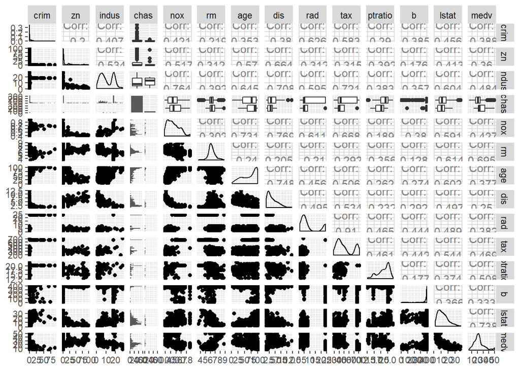

```r
library(caret)
library(AppliedPredictiveModeling)
library(mlbench)
data(BostonHousing)

set.seed(280)
bh_index <- createDataPartition(BostonHousing$medv, p=.75, list=FALSE)
bh_tr <- BostonHousing[bh_index,]
bh_te <- BostonHousing[-bh_index,]

set.seed(7229)
lm_fit <- train(medv~. + rm:lstat,
                data=bh_tr,
                method="lm")
bh_pred <- predict(lm_fit, bh_te)

GGally::ggpairs(BostonHousing)
```

```r
lm_fit
```

```
## Linear Regression
##
## 381 samples
##  13 predictor
##
## No pre-processing
## Resampling: Bootstrapped (25 reps)
## Summary of sample sizes: 381, 381, 381, 381, 381, 381, ...
## Resampling results:
##
##   RMSE      Rsquared  MAE
##   4.250365  0.777112  2.928805
##
## Tuning parameter 'intercept' was held constant at a value of TRUE
```

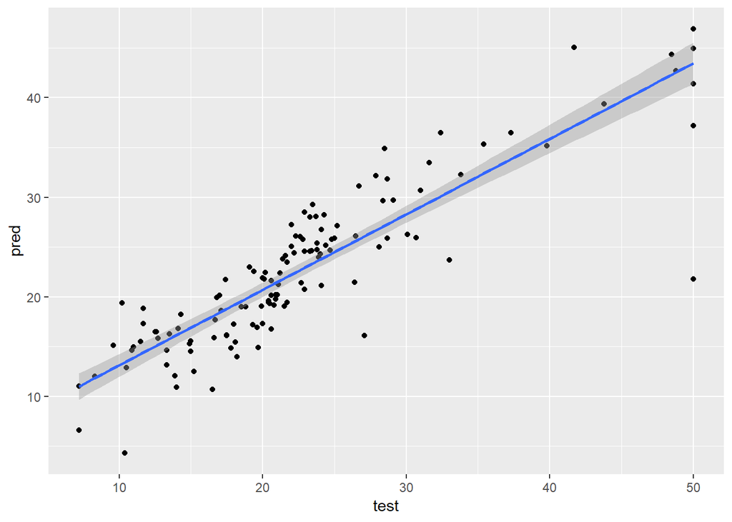

```r
library(tidyverse)

summary <- tibble::tibble(
  test = bh_te$medv,
  pred = bh_pred)
summary %>%
  ggplot(aes(test, pred))+
  geom_point()+
  geom_smooth(method = "lm")
```

```r
postResample(pred=bh_pred, obs=bh_te$medv)
```

```
##      RMSE  Rsquared       MAE
## 4.4412987 0.7781877 3.0926842
```

A note about how $R^2$ is calculated by `caret`: it takes the straightforward approach of computing the correlation between the observed and predicted values (i.e. R) and squaring the value. When the model is poor, this can lead to differences between this estimator and the more widely known estimate derived form linear regression models. Mostly notably, the correlation approach will not generate negative values of $R^2$ (which are theoretically invalid). A comparison of these and other estimators can be found in Kvalseth 1985.

## Measures for predicted classes

Before proceeding, let’s make up some test set data:

```r
set.seed(144)
true_class <- factor(sample(paste0("Class",1:2),
                            size=1000,
                            prob=c(.2, .8),replace=TRUE))

true_class <- sort(true_class)
class1_probs <- rbeta(sum(true_class == "Class1"), 4, 1)
class2_probs <- rbeta(sum(true_class == "Class2"), 1, 2.5)
test_set <- data.frame(obs = true_class,
                       Class1 = c(class1_probs, class2_probs))
test_set$Class2 <- 1 - test_set$Class1
test_set$pred <- factor(ifelse(test_set$Class1 >= .5, "Class1", "Class2"))
```

We would expect that this model will do well on these data:

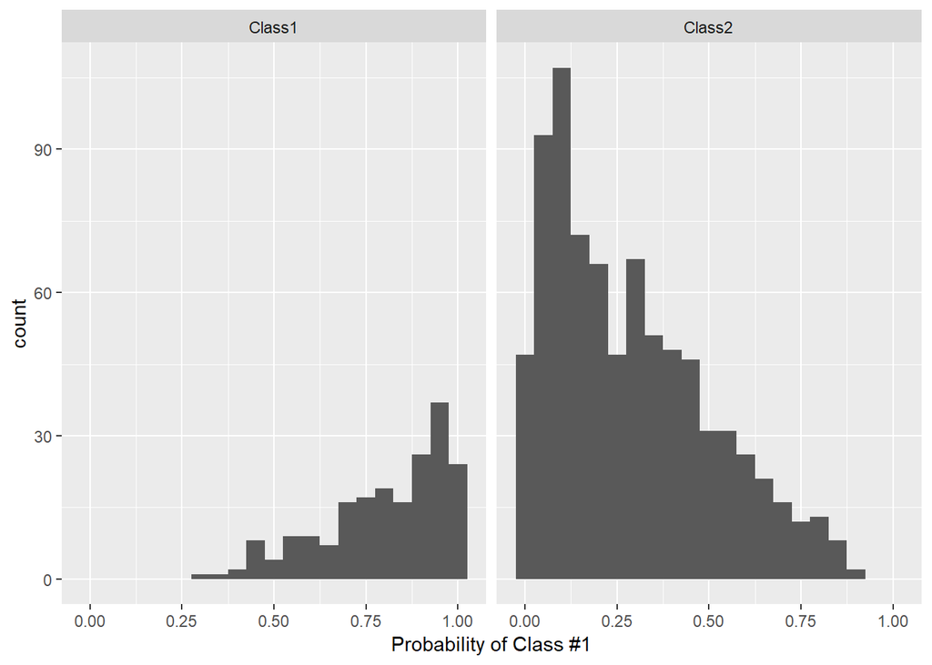

```r
ggplot(test_set, aes(x=Class1))+
  geom_histogram(binwidth=.05)+
  facet_wrap(~obs)+
  xlab("Probability of Class #1")
```

Generating the predicted classes based on the typical 50% cutoff for the probabilities, we can compute the confusion matrix, which shows a cross-tabulation of the observed and predicted classes. The confusionMatrix function can be used to generate these results:

```r
confusionMatrix(data=test_set$pred, reference = test_set$obs)
```

```
## Confusion Matrix and Statistics
##
##           Reference
## Prediction Class1 Class2
##     Class1    183    141
##     Class2     13    663
##
##                Accuracy : 0.846
##                  95% CI : (0.8221, 0.8678)
##     No Information Rate : 0.804
##     P-Value [Acc > NIR] : 0.0003424
##
##                   Kappa : 0.6081
##  Mcnemar's Test P-Value : < 2.2e-16
##
##             Sensitivity : 0.9337
##             Specificity : 0.8246
##          Pos Pred Value : 0.5648
##          Neg Pred Value : 0.9808
##              Prevalence : 0.1960
##          Detection Rate : 0.1830
##    Detection Prevalence : 0.3240
##       Balanced Accuracy : 0.8792
##
##        'Positive' Class : Class1
##
```

For two classes, this function assumes that the class corresponding to an event is the first class level (but this can be changed using the `positive` argument.

Note that there are a number of statistics shown here. The **“no-information rate”** is the largest proportion of the observed classes (there were more class 2 data than class 1 in this test set). A hypothesis test is also computed to evaluate whether the overall accuracy rate is greater than the rate of the largest class. Also, the prevalence of the “positive event” is computed from the data (unless passed in as an argument), the detection rate (the rate of true events also predicted to be events) and the detection prevalence (the prevalence of predicted events).

If the prevalence of the event is different than those seen in the test set, the `prevalence` option can be used to adjust this.

The formulas used here are: - Sensitivity = $\frac{A}{A+C}$ - Specificity=$\frac{D}{B+D}$ - Prevalance=$\frac{A+C}{A+B+C+D}$ - RPV = $\frac{sensitivity*prevalence}{(sensitivity*prevalance)+(1-specificity)*(1-prevalanceb)}$ - NPV = $\frac{sensitivity*prevalence}{((1-sensitivity)*prevalance)+(1-specificity)*(1-prevalanceb)}$ - Detection rate = $\frac{A}{A+B+C+D}$ - Detenction prevalence = $\frac{A+B}{A+B+C+D}$ - Balanced accuracy = $(sensitivity + specificity)/2$ - Precision = $\frac{A}{A+B}$ - Recall = $\frac{A}{A+C}$ - F1 = $\frac{(1+\beta^2)*precision*recall}{\beta^2*precision+recall}$

When there are three or more classes, `confusionMatrix` will show the confusion matrix and a set of “one-versus-all” results. For example, in a three class problem, the sensitivity of the first class is calculated against all the samples in the second and third classes (and so on).

The `confusionMatrix` matrix frames the errors in terms of sensitivity and specificity. In the case of information retrieval, the precision and recall might be more appropriate. In this case, the option `mode` can be used to get those statistics:

```r
confusionMatrix(data=test_set$pred, reference=test_set$obs, mode="prec_recall")
```

```
## Confusion Matrix and Statistics
##
##           Reference
## Prediction Class1 Class2
##     Class1    183    141
##     Class2     13    663
##
##                Accuracy : 0.846
##                  95% CI : (0.8221, 0.8678)
##     No Information Rate : 0.804
##     P-Value [Acc > NIR] : 0.0003424
##
##                   Kappa : 0.6081
##  Mcnemar's Test P-Value : < 2.2e-16
##
##               Precision : 0.5648
##                  Recall : 0.9337
##                      F1 : 0.7038
##              Prevalence : 0.1960
##          Detection Rate : 0.1830
##    Detection Prevalence : 0.3240
##       Balanced Accuracy : 0.8792
##
##        'Positive' Class : Class1
##
```

Again, the `positive` argument can be used to control which factor level is associated with a “found” or “important” document or sample.

There are individual functions called `sensitivity`, `specificity`, `posPredValue`, `negPredValue`, `precision`, `recall`, and `F_meas`.

Also, a resampled estimate of the training set can also be obtained using `confusionMatrix.train`. For each resampling iteration, a confusion matrix is created from the hold-out samples and these values can be aggregated to diagnose issues with the model fit.

The default performance function used by `train` is `postResample`, which generates the accuracy and Kappa statistics:

```r
postResample(pred=test_set$pred, obs=test_set$obs)
```

```
##  Accuracy     Kappa
## 0.8460000 0.6081345
```

As shown below, another function called `twoClassSummary` can be used to get the sensitivity and specificity using the default probability cutoff. Another function, `multiClassSummary`, can do similar calculations when there are three or more classes but both require class probabilities for each class.

## Measures for class probabilities

For data with two classes, there are specialized functions for measuring model performance. First, the twoClassSummary function computes the area under the ROC curve and the specificity and sensitivity under the 50% cutoff. Note that:

this function uses the first class level to define the “event” of interest. To change this, use the lev option to the function there must be columns in the data for each of the class probabilities (named the same as the outcome’s class levels)